# Lab 5: Average Treatment Effect

Causal Machine Learning

Stijn Vansteelandt and Federico Bertoia, Ghent University

2026-03-16

## 0. Introduction

The goal of this lab is to estimate the **Average Treatment Effect (ATE)**, defined as:

$$E[Y^1 - Y^0],$$

where $Y^a$ denotes the potential outcome had treatment been set to $A = a$. Under the standard causal assumptions of **consistency**, **positivity**, and **conditional exchangeability**, the ATE is nonparametrically identified from observed data as:

$$\text{ATE} = E\Big[E[Y \mid A=1, X] - E[Y \mid A=0, X]\Big].$$

We implement and compare four estimators:

1. **G-Computation**
2. **IPW** (Inverse Probability Weighting)
3. **AIPW** (Augmented IPW)
4. **TMLE** (Targeted Maximum Likelihood Estimation)

### Data

The dataset comes from an observational study conducted at Ohio Heart Health (1997), comprising **996 patients** who underwent Percutaneous Coronary Intervention (PCI). Patients received PCI either with or without adjunct therapy using **abciximab**, a glycoprotein IIb/IIIa inhibitor that reduces platelet aggregation.

Importantly, abciximab was preferentially administered to **more severely diseased patients**, introducing *confounding* — a classic challenge in observational studies. All patients were followed for at least 6 months by the Lindner Center staff, and the binary outcome of interest is **survival at 6 months**.

```r
# ── Packages ──────────────────────────────────────────────────────────────────
library(twang)
library(tibble)
library(dplyr)
library(tidyr)
library(ggplot2)
library(SuperLearner)
library(tmle)

# ── Reproducibility ───────────────────────────────────────────────────────────
set.seed(123)

# ── Load data ─────────────────────────────────────────────────────────────────
data(lindner)

lindner <- lindner %>%
  mutate(survival_binary = ifelse(sixMonthSurvive == FALSE, 1, 0)) %>%
  select(-sixMonthSurvive)

# ── Initial inspection ────────────────────────────────────────────────────────
glimpse(lindner)
```

```
## Rows: 996
## Columns: 11
## $ lifepres        <dbl> 0.0, 11.6, 11.6, 11.6, 11.6, 11.6, 11.6, 11.6, 11.6, 1…
## $ cardbill        <int> 14301, 3563, 4694, 7366, 8247, 8319, 8410, 8517, 8763,…
## $ abcix           <int> 1, 1, 1, 1, 1, 1, 1, 1, 1, 1, 1, 1, 1, 1, 1, 1, 1, 1, …
## $ stent           <int> 0, 0, 0, 0, 0, 0, 0, 0, 0, 0, 0, 0, 0, 0, 0, 0, 0, 0, …
## $ height          <int> 163, 168, 188, 175, 168, 178, 185, 173, 152, 180, 152,…
## $ female          <int> 1, 0, 0, 0, 1, 0, 0, 1, 1, 0, 1, 1, 0, 1, 0, 1, 0, 1, …
## $ diabetic        <int> 1, 0, 0, 1, 0, 0, 0, 0, 0, 0, 0, 0, 1, 1, 0, 0, 0, 0, …
## $ acutemi         <int> 0, 0, 0, 0, 0, 0, 0, 0, 0, 0, 0, 0, 0, 0, 0, 0, 0, 0, …
## $ ejecfrac        <int> 56, 56, 50, 50, 55, 50, 58, 30, 60, 60, 60, 50, 40, 65…
## $ ves1proc        <int> 1, 1, 1, 1, 1, 1, 1, 1, 1, 1, 1, 1, 1, 1, 1, 1, 1, 1, …
## $ survival_binary <dbl> 1, 0, 0, 0, 0, 0, 0, 0, 0, 0, 0, 0, 0, 0, 0, 0, 0, 0, …
```

```r
# Confirm no missing values
stopifnot(all(colSums(is.na(lindner)) == 0))
```

## 1. Exploratory Data Analysis

Before estimating the ATE, we briefly explore the data to understand the distribution of the treatment, outcome, and key covariates.

### 1.1 Treatment and outcome distribution

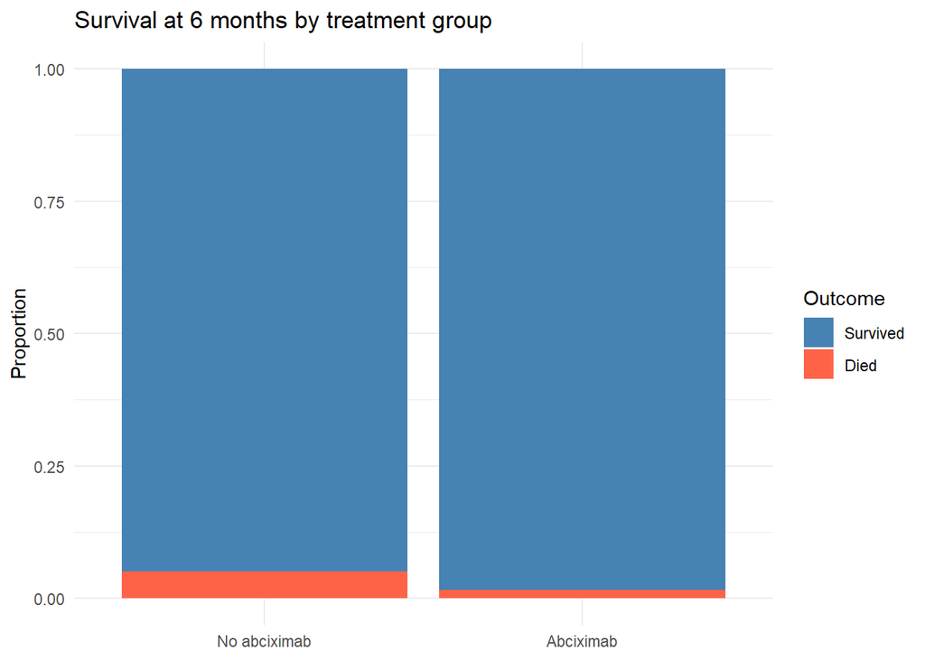

```r
lindner %>%
  count(abcix, survival_binary) %>%
  mutate(
    abcix           = factor(abcix, labels = c("No abciximab", "Abciximab")),
    survival_binary = factor(survival_binary, labels = c("Survived", "Died"))
  ) %>%
  ggplot(aes(x = abcix, y = n, fill = survival_binary)) +
  geom_col(position = "fill") +
  scale_fill_manual(values = c("steelblue", "tomato")) +
  theme_minimal() +
  labs(x = NULL, y = "Proportion", fill = "Outcome",
       title = "Survival at 6 months by treatment group")
```

### 1.2 Covariate distributions by treatment

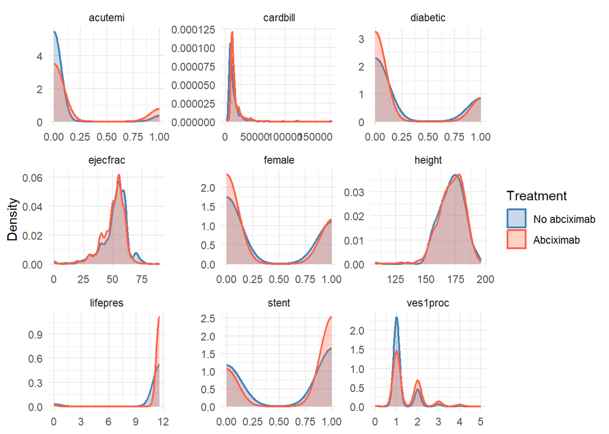

```r
lindner %>%
  select(-survival_binary) %>%
  mutate(abcix = factor(abcix, labels = c("No abciximab", "Abciximab"))) %>%
  pivot_longer(cols = -abcix, names_to = "variable", values_to = "value") %>%
  ggplot(aes(x = value, fill = abcix, color = abcix)) +
  geom_density(alpha = 0.3, linewidth = 0.8) +
  facet_wrap(~variable, scales = "free") +
  scale_fill_manual(values  = c("steelblue", "tomato")) +
  scale_color_manual(values = c("steelblue", "tomato")) +
  theme_minimal() +
  labs(x = NULL, y = "Density", fill = "Treatment", color = "Treatment")
```

## 2. Unadjusted Risk Difference and Odds Ratio

Before turning to causal estimators, we compute two simple unadjusted measures of association between treatment and outcome: the **risk difference** (RD) and the **odds ratio** (OR). These do not adjust for confounding and serve as a naive baseline.

### 2.1 Risk Difference

The risk difference is estimated via a linear probability model:

$$E(Y \mid A) = \alpha + \beta A$$

where $\hat{\beta}$ directly estimates the risk difference $P(Y = 1 \mid A = 1) - P(Y = 1 \mid A = 0)$.

### 2.2 Odds Ratio

The odds ratio is estimated via logistic regression:

$$\text{logit}\, P(Y = 1 \mid A) =
\alpha^* + \beta^* A$$

The odds ratio is then recovered as:

$$\widehat{\text{OR}} =
\exp(\hat{\beta}^*) = \frac{\text{odds}(Y = 1 \mid A = 1)}{\text{odds}(Y
= 1 \mid A = 0)}$$

```r
# ── Contingency table ─────────────────────────────────────────────────────────
table(lindner$survival_binary, lindner$abcix)
```

```
##
##       0   1
##   0 283 687
##   1  15  11
```

```r
# ── Model formulas ────────────────────────────────────────────────────────────
unadjusted <- survival_binary ~ abcix

# ── Risk Difference (linear probability model) ────────────────────────────────
lpm_fit <- lm(unadjusted, data = lindner)
summary(lpm_fit)
```

```
##
## Call:
## lm(formula = unadjusted, data = lindner)
##
## Residuals:
##      Min       1Q   Median       3Q      Max
## -0.05034 -0.05034 -0.01576 -0.01576  0.98424
##
## Coefficients:
##             Estimate Std. Error t value Pr(>|t|)
## (Intercept)  0.05034    0.00920   5.471 5.66e-08 ***
## abcix       -0.03458    0.01099  -3.146   0.0017 **
## ---
## Signif. codes:  0 '***' 0.001 '**' 0.01 '*' 0.05 '.' 0.1 ' ' 1
##
## Residual standard error: 0.1588 on 994 degrees of freedom
## Multiple R-squared:  0.00986,    Adjusted R-squared:  0.008864
## F-statistic: 9.899 on 1 and 994 DF,  p-value: 0.001703
```

```r
confint(lpm_fit)
```

```
##                   2.5 %      97.5 %
## (Intercept)  0.03228184  0.06838930
## abcix       -0.05614223 -0.01301029
```

```r
rd    <- coef(lpm_fit)["abcix"]
ci_rd <- confint(lpm_fit)["abcix", ]

cat("Risk Difference:", round(rd, 4), "\n")
```

```
## Risk Difference: -0.0346
```

```r
cat("95% CI: [", round(ci_rd[1], 4), ",", round(ci_rd[2], 4), "]\n")
```

```
## 95% CI: [ -0.0561 , -0.013 ]
```

```r
# ── Odds Ratio (logistic regression) ─────────────────────────────────────────
logit_fit <- glm(unadjusted, data = lindner, family = binomial())
summary(logit_fit)
```

```
##
## Call:
## glm(formula = unadjusted, family = binomial(), data = lindner)
##
## Coefficients:
##             Estimate Std. Error z value Pr(>|z|)
## (Intercept)  -2.9374     0.2650 -11.086  < 2e-16 ***
## abcix        -1.1970     0.4032  -2.969  0.00299 **
## ---
## Signif. codes:  0 '***' 0.001 '**' 0.01 '*' 0.05 '.' 0.1 ' ' 1
##
## (Dispersion parameter for binomial family taken to be 1)
##
##     Null deviance: 240.89  on 995  degrees of freedom
## Residual deviance: 232.04  on 994  degrees of freedom
## AIC: 236.04
##
## Number of Fisher Scoring iterations: 7
```

```r
or    <- exp(coef(logit_fit)["abcix"])
ci_or <- exp(confint(logit_fit)["abcix", ])

cat("Odds Ratio:", round(or, 4), "\n")
```

```
## Odds Ratio: 0.3021
```

```r
cat("95% CI: [", round(ci_or[1], 4), ",", round(ci_or[2], 4), "]\n")
```

```
## 95% CI: [ 0.1337 , 0.6619 ]
```

## 3. Setup

We define the outcome $Y$, treatment $A$, and covariate matrix $X$ used by all four estimators.

```r
# ── Outcome, treatment, covariates ────────────────────────────────────────────
Y <- lindner$survival_binary
A <- lindner$abcix
X <- lindner %>% select(-survival_binary, -abcix)

N <- nrow(lindner)

# ── Candidate learners ────────────────────────────────────────────────────────
SL.library <- c("SL.mean", "SL.glm", "SL.ranger", "SL.gam", "SL.earth")

# ── Cross-fitting folds ───────────────────────────────────────────────────────
n_folds <- 5
fold_id <- sample(rep(1:n_folds, length.out = N))
folds   <- split(seq_len(N), fold_id)
```

## 4. G-Computation

G-Computation (also called the *substitution estimator*) proceeds in two steps. First, fit an outcome model $\hat{Q}(a, x) = \hat{E}[Y \mid A = a, X = x]$. Second, plug in $A = 1$ and $A = 0$ for every unit and average the difference in predicted potential outcomes:

$$\widehat{\text{ATE}}_{\text{G-comp}} = \frac{1}{n} \sum_{i=1}^{n}
\left[ \hat{Q}(1, X_i) - \hat{Q}(0, X_i) \right].$$

### 4.1 Parametric outcome model

We first fit a parametric logistic regression for $Q(a, x)$ and obtain the ATE by hand. Standard errors are then computed via `stdReg`, which uses a sandwich estimator for the variance of $\hat{E}[Y^1]$ and $\hat{E}[Y^0]$:

$$\widehat{\text{var}}\left(\hat{E}[Y^1 - Y^0]\right) =
\widehat{\text{var}}\left(\hat{E}[Y^1]\right) +
\widehat{\text{var}}\left(\hat{E}[Y^0]\right) -
2\,\widehat{\text{cov}}\left(\hat{E}[Y^1], \hat{E}[Y^0]\right)$$

```r
# ── Model formula ─────────────────────────────────────────────────────────────
formula_gcomp <- as.formula(paste("Y ~ A +", paste(colnames(X), collapse = " + ")))

# ── Fit parametric outcome model ──────────────────────────────────────────────
glm_Q <- glm(formula_gcomp, family = binomial(), data = data.frame(Y, A, X))

# ── Predict potential outcomes by hand ───────────────────────────────────────
dat0 <- data.frame(Y, A = 0, X)
dat1 <- data.frame(Y, A = 1, X)

Q0_par <- predict(glm_Q, newdata = dat0, type = "response")
Q1_par <- predict(glm_Q, newdata = dat1, type = "response")

ate_gcomp_par <- mean(Q1_par - Q0_par)
cat("G-Computation ATE (parametric, by hand):", round(ate_gcomp_par, 4), "\n")
```

```
## G-Computation ATE (parametric, by hand): 0
```

```r
# ── Standard error via stdReg (sandwich estimator) ────────────────────────────
library(stdReg)
fit_std <- stdGlm(fit = glm_Q, data = data.frame(Y, A, X), X = "A")
print(summary(fit_std))
```

```
##
## Formula: Y ~ A + lifepres + cardbill + stent + height + female + diabetic +
##     acutemi + ejecfrac + ves1proc
## Family: binomial
## Link function: logit
## Exposure:  A
##
##   Estimate Std. Error lower 0.95 upper 0.95
## 0   0.0261    0.00505     0.0162      0.036
## 1   0.0261    0.00505     0.0162      0.036
```

```r
ate_gcomp_par_se <- sqrt(fit_std$vcov[1] + fit_std$vcov[4] - 2 * fit_std$vcov[3])
ci_gcomp_par    <- ate_gcomp_par + c(-1, 1) * 1.96 * ate_gcomp_par_se

cat("G-Computation ATE (parametric):", round(ate_gcomp_par, 4), "\n")
```

```
## G-Computation ATE (parametric): 0
```

```r
cat("SE:", round(ate_gcomp_par_se, 4), "\n")
```

```
## SE: 0
```

```r
cat("95% CI: [", round(ci_gcomp_par[1], 4), ",", round(ci_gcomp_par[2], 4), "]\n")
```

```
## 95% CI: [ 0 , 0 ]
```

### 4.2 Non-parametric outcome model (Super Learner)

We now replace the parametric logistic regression with a Super Learner ensemble, which avoids model misspecification but introduces **plug-in bias** — nonparametric estimators converge at slower rates, making valid confidence intervals unavailable in this setting.

```r
# ── Without cross-fitting ─────────────────────────────────────────────────────
sl_Q <- SuperLearner(
  Y          = Y,
  X          = data.frame(A = A, X),
  SL.library = SL.library,
  family     = binomial(),
  method     = "method.NNLS",
  cvControl  = list(V = 5)
)

Q1 <- predict(sl_Q, newdata = data.frame(A = 1, X))$pred
Q0 <- predict(sl_Q, newdata = data.frame(A = 0, X))$pred

ate_gcomp <- mean(Q1 - Q0)
cat("G-Computation ATE (no cross-fitting):", round(ate_gcomp, 4), "\n")
```

```
## G-Computation ATE (no cross-fitting): 0
```

```r
# ── With cross-fitting ────────────────────────────────────────────────────────
Q1_cf <- numeric(N)
Q0_cf <- numeric(N)

for (k in 1:n_folds) {

  test  <- folds[[k]]
  train <- setdiff(seq_len(N), test)

  sl_Q_cf <- SuperLearner(
    Y          = Y[train],
    X          = data.frame(A = A[train], X[train, ]),
    SL.library = SL.library,
    family     = binomial(),
    method     = "method.NNLS",
    cvControl  = list(V = 5)
  )

  Q1_cf[test] <- predict(sl_Q_cf, newdata = data.frame(A = 1, X[test, ]))$pred
  Q0_cf[test] <- predict(sl_Q_cf, newdata = data.frame(A = 0, X[test, ]))$pred
}

ate_gcomp_cf <- mean(Q1_cf - Q0_cf)
cat("G-Computation ATE (cross-fitting):", round(ate_gcomp_cf, 4), "\n")
```

```
## G-Computation ATE (cross-fitting): 0
```

## 5. IPW

The Inverse Probability Weighting (IPW) estimator reweights observations by the inverse of their propensity score $\hat{\pi}(x) = \hat{P}(A = 1 \mid X = x)$, upweighting units whose treatment assignment was unlikely given their covariates.

$$\widehat{\text{ATE}}_{\text{IPW}} = \frac{1}{n} \sum_{i=1}^{n}
\left( \frac{A_i Y_i}{\hat{\pi}(X_i)} - \frac{(1-A_i) Y_i}{1 -
\hat{\pi}(X_i)} \right)$$

### 5.1 Parametric propensity score model

```r
# ── Fit parametric propensity score model ─────────────────────────────────────
library(sandwich)

formula_g  <- as.formula(paste("A ~", paste(colnames(X), collapse = " + ")))
glm_pi     <- glm(formula_g, family = binomial(), data = data.frame(A, X))
pi_hat_par <- glm_pi$fitted.values

# ── Positivity check ──────────────────────────────────────────────────────────
summary(pi_hat_par)
```

```
##    Min. 1st Qu.  Median    Mean 3rd Qu.    Max.
##  0.1215  0.6067  0.6956  0.7008  0.8102  0.9802
```

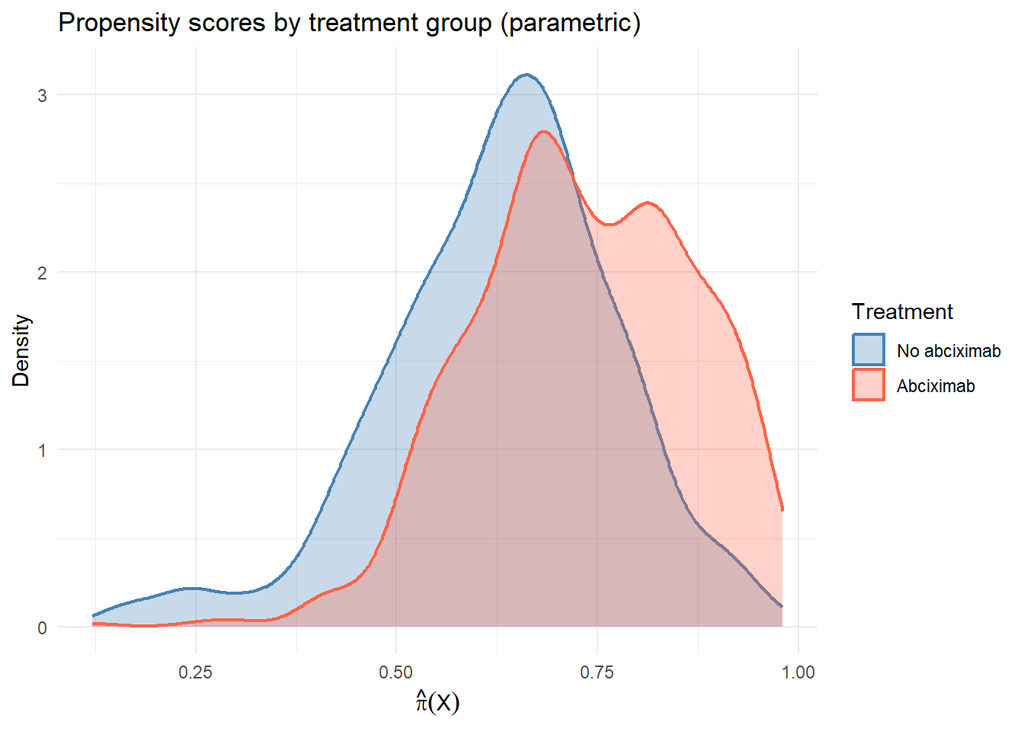

```r
data.frame(pi_hat = pi_hat_par, A = factor(A, labels = c("No abciximab", "Abciximab"))) %>%
  ggplot(aes(x = pi_hat, fill = A, color = A)) +
  geom_density(alpha = 0.3, linewidth = 0.8) +
  scale_fill_manual(values  = c("steelblue", "tomato")) +
  scale_color_manual(values = c("steelblue", "tomato")) +
  theme_minimal() +
  labs(x     = expression(hat(pi)(X)),
       y     = "Density",
       fill  = "Treatment",
       color = "Treatment",
       title = "Propensity scores by treatment group (parametric)")
```

```r
# ── Weighted linear regression ────────────────────────────────────────────────
weights_par <- A / pi_hat_par + (1 - A) / (1 - pi_hat_par)
fit_ipw_par <- lm(Y ~ A, weights = weights_par)

ate_ipw_par    <- coef(fit_ipw_par)["A"]
ate_ipw_par_se <- sqrt(vcovHC(fit_ipw_par, type = "HC")["A", "A"])
ci_ipw_par     <- ate_ipw_par + c(-1, 1) * 1.96 * ate_ipw_par_se

cat("IPW ATE (parametric, weighted regression):", round(ate_ipw_par, 4), "\n")
```

```
## IPW ATE (parametric, weighted regression): -0.0025
```

```r
cat("SE:", round(ate_ipw_par_se, 4), "\n")
```

```
## SE: 0.0154
```

```r
cat("95% CI: [", round(ci_ipw_par[1], 4), ",", round(ci_ipw_par[2], 4), "]\n")
```

```
## 95% CI: [ -0.0327 , 0.0276 ]
```

### 5.2 Non-parametric propensity score model (Super Learner)

We now replace the parametric logistic regression with a Super Learner ensemble. For each estimator we report both the Horvitz-Thompson estimator (direct plug-in) and the weighted linear regression, which provides standard errors via the HC sandwich estimator.

```r
# ── Without cross-fitting ─────────────────────────────────────────────────────
sl_pi <- SuperLearner(
  Y          = A,
  X          = X,
  SL.library = SL.library,
  family     = binomial(),
  method     = "method.NNLS",
  cvControl  = list(V = 5)
)

pi_hat <- predict(sl_pi, newdata = X)$pred

# ── Positivity check ──────────────────────────────────────────────────────────
summary(pi_hat)
```

```
##        V1
##  Min.   :0.06024
##  1st Qu.:0.60608
##  Median :0.77725
##  Mean   :0.70057
##  3rd Qu.:0.87743
##  Max.   :0.98146
```

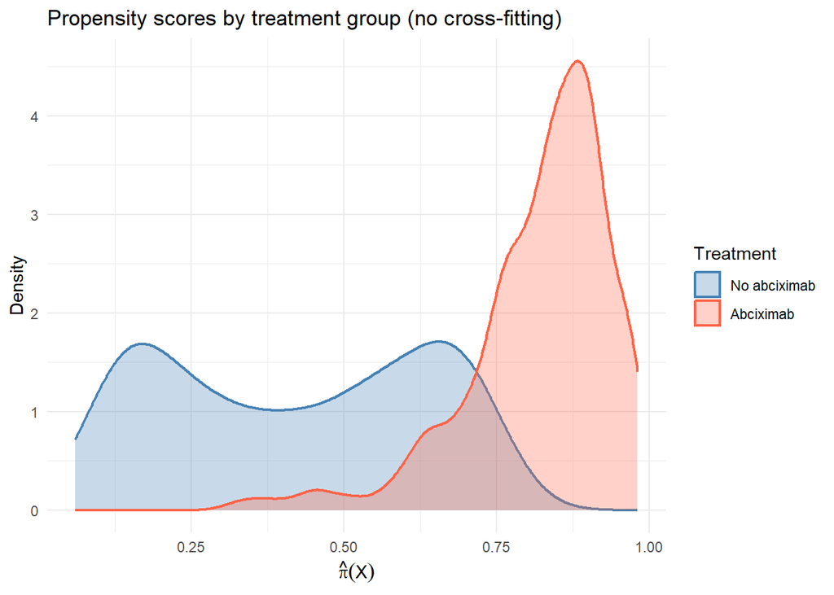

```r
data.frame(pi_hat = pi_hat, A = factor(A, labels = c("No abciximab", "Abciximab"))) %>%
  ggplot(aes(x = pi_hat, fill = A, color = A)) +
  geom_density(alpha = 0.3, linewidth = 0.8) +
  scale_fill_manual(values  = c("steelblue", "tomato")) +
  scale_color_manual(values = c("steelblue", "tomato")) +
  theme_minimal() +
  labs(x     = expression(hat(pi)(X)),
       y     = "Density",
       fill  = "Treatment",
       color = "Treatment",
       title = "Propensity scores by treatment group (no cross-fitting)")
```

```r
# ── Horvitz-Thompson estimator ────────────────────────────────────────────────
ipw_weights <- A / pi_hat - (1 - A) / (1 - pi_hat)
ate_ipw     <- mean(ipw_weights * Y)
cat("IPW ATE - Horvitz-Thompson (no cross-fitting):", round(ate_ipw, 4), "\n")
```

```
## IPW ATE - Horvitz-Thompson (no cross-fitting): -0.0045
```

```r
# ── Weighted linear regression ────────────────────────────────────────────────
weights_sl  <- A / pi_hat + (1 - A) / (1 - pi_hat)
fit_ipw_sl  <- lm(Y ~ A, weights = weights_sl)

ate_ipw_sl    <- coef(fit_ipw_sl)["A"]
ate_ipw_sl_se <- sqrt(vcovHC(fit_ipw_sl, type = "HC")["A", "A"])
ci_ipw_sl     <- ate_ipw_sl + c(-1, 1) * 1.96 * ate_ipw_sl_se

cat("IPW ATE - weighted regression (no cross-fitting):", round(ate_ipw_sl, 4), "\n")
```

```
## IPW ATE - weighted regression (no cross-fitting): -0.0165
```

```r
cat("SE:", round(ate_ipw_sl_se, 4), "\n")
```

```
## SE: 0.0115
```

```r
cat("95% CI: [", round(ci_ipw_sl[1], 4), ",", round(ci_ipw_sl[2], 4), "]\n")
```

```
## 95% CI: [ -0.0391 , 0.0062 ]
```

```r
# ── With cross-fitting ────────────────────────────────────────────────────────
pi_hat_cf <- numeric(N)

for (k in 1:n_folds) {

  test  <- folds[[k]]
  train <- setdiff(seq_len(N), test)

  sl_pi_cf <- SuperLearner(
    Y          = A[train],
    X          = X[train, ],
    SL.library = SL.library,
    family     = binomial(),
    method     = "method.NNLS",
    cvControl  = list(V = 5)
  )

  pi_hat_cf[test] <- predict(sl_pi_cf, newdata = X[test, ])$pred
}

# ── Positivity check ──────────────────────────────────────────────────────────
summary(pi_hat_cf)
```

```
##    Min. 1st Qu.  Median    Mean 3rd Qu.    Max.
## 0.05394 0.61007 0.77583 0.69418 0.85707 0.98028
```

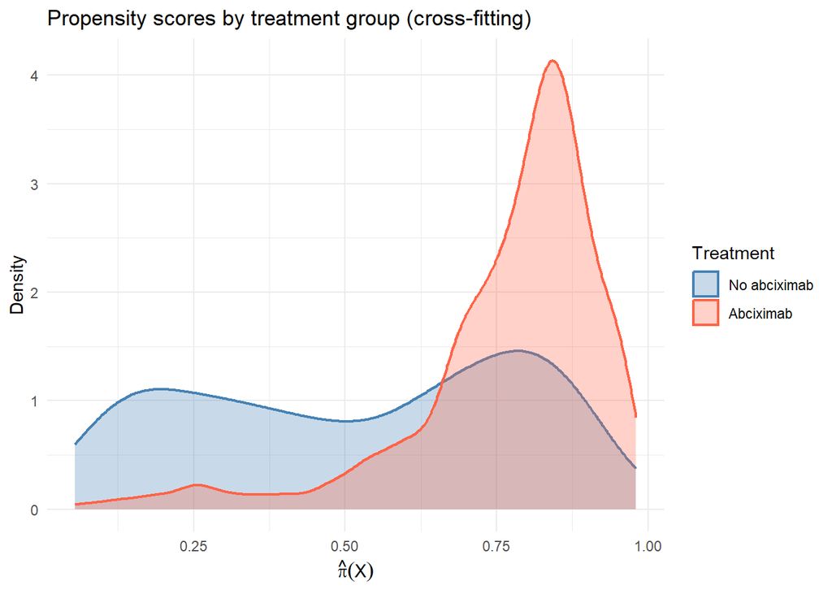

```r
data.frame(pi_hat_cf = pi_hat_cf, A = factor(A, labels = c("No abciximab", "Abciximab"))) %>%
  ggplot(aes(x = pi_hat_cf, fill = A, color = A)) +
  geom_density(alpha = 0.3, linewidth = 0.8) +
  scale_fill_manual(values  = c("steelblue", "tomato")) +
  scale_color_manual(values = c("steelblue", "tomato")) +
  theme_minimal() +
  labs(x     = expression(hat(pi)(X)),
       y     = "Density",
       fill  = "Treatment",
       color = "Treatment",
       title = "Propensity scores by treatment group (cross-fitting)")
```

```r
# ── Horvitz-Thompson estimator ────────────────────────────────────────────────
ipw_weights_cf <- A / pi_hat_cf - (1 - A) / (1 - pi_hat_cf)
ate_ipw_cf     <- mean(ipw_weights_cf * Y)
cat("IPW ATE - Horvitz-Thompson (cross-fitting):", round(ate_ipw_cf, 4), "\n")
```

```
## IPW ATE - Horvitz-Thompson (cross-fitting): 0.0082
```

```r
# ── Weighted linear regression ────────────────────────────────────────────────
weights_sl_cf  <- A / pi_hat_cf + (1 - A) / (1 - pi_hat_cf)
fit_ipw_sl_cf  <- lm(Y ~ A, weights = weights_sl_cf)

ate_ipw_cf_sl    <- coef(fit_ipw_sl_cf)["A"]
ate_ipw_cf_sl_se <- sqrt(vcovHC(fit_ipw_sl_cf, type = "HC")["A", "A"])
ci_ipw_cf_sl     <- ate_ipw_cf_sl + c(-1, 1) * 1.96 * ate_ipw_cf_sl_se

cat("IPW ATE - weighted regression (cross-fitting):", round(ate_ipw_cf_sl, 4), "\n")
```

```
## IPW ATE - weighted regression (cross-fitting): 0.0082
```

```r
cat("SE:", round(ate_ipw_cf_sl_se, 4), "\n")
```

```
## SE: 0.0202
```

```r
cat("95% CI: [", round(ci_ipw_cf_sl[1], 4), ",", round(ci_ipw_cf_sl[2], 4), "]\n")
```

```
## 95% CI: [ -0.0313 , 0.0477 ]
```

## 6. AIPW

The Augmented IPW (AIPW) estimator combines the outcome model and the propensity score into a single *doubly robust* estimator: it remains consistent if either (but not necessarily both) nuisance models are correctly specified.

$$\widehat{\text{ATE}}_{\text{AIPW}} = \frac{1}{n} \sum_{i=1}^{n}
\left[
\hat{Q}(1, X_i) - \hat{Q}(0, X_i)
+ \frac{A_i (Y_i - \hat{Q}(1, X_i))}{\hat{\pi}(X_i)}
- \frac{(1 - A_i)(Y_i - \hat{Q}(0, X_i))}{1 - \hat{\pi}(X_i)}
\right]$$

```r
# ── Without cross-fitting ─────────────────────────────────────────────────────
aug_1    <-  A      * (Y - Q1) / pi_hat
aug_0    <- (1 - A) * (Y - Q0) / (1 - pi_hat)
psi_i    <- (Q1 - Q0) + aug_1 - aug_0
ate_aipw <- mean(psi_i)
se_aipw  <- sd(psi_i) / sqrt(N)
ci_aipw  <- ate_aipw + c(-1, 1) * 1.96 * se_aipw

cat("AIPW ATE (no cross-fitting):", round(ate_aipw, 4), "\n")
```

```
## AIPW ATE (no cross-fitting): 0
```

```r
cat("95% CI: [", round(ci_aipw[1], 4), ",", round(ci_aipw[2], 4), "]\n")
```

```
## 95% CI: [ 0 , 0 ]
```

```r
# ── With cross-fitting ────────────────────────────────────────────────────────
aug_1_cf    <-  A      * (Y - Q1_cf) / pi_hat_cf
aug_0_cf    <- (1 - A) * (Y - Q0_cf) / (1 - pi_hat_cf)
psi_i_cf    <- (Q1_cf - Q0_cf) + aug_1_cf - aug_0_cf
ate_aipw_cf <- mean(psi_i_cf)
se_aipw_cf  <- sd(psi_i_cf) / sqrt(N)
ci_aipw_cf  <- ate_aipw_cf + c(-1, 1) * 1.96 * se_aipw_cf

cat("AIPW ATE (cross-fitting):", round(ate_aipw_cf, 4), "\n")
```

```
## AIPW ATE (cross-fitting): 0
```

```r
cat("95% CI: [", round(ci_aipw_cf[1], 4), ",", round(ci_aipw_cf[2], 4), "]\n")
```

```
## 95% CI: [ 0 , 0 ]
```

## 7. TMLE

Targeted Maximum Likelihood Estimation (TMLE) is a doubly robust substitution estimator. Unlike AIPW, it updates (targets) the initial outcome model via a fluctuation step that uses the propensity score, ensuring the final estimate solves the efficient score equation exactly. We use the `tmle` package.

```r
# ── Without cross-fitting ─────────────────────────────────────────────────────
tmle_fit <- tmle(
  Y            = Y,
  A            = A,
  W            = as.data.frame(X),
  Q.SL.library = SL.library,
  g.SL.library = SL.library,
  family       = "binomial"
)

ate_tmle <- tmle_fit$estimates$ATE$psi
ci_tmle  <- tmle_fit$estimates$ATE$CI

cat("TMLE ATE (no cross-fitting):", round(ate_tmle, 4), "\n")
```

```
## TMLE ATE (no cross-fitting): 0
```

```r
cat("95% CI: [", round(ci_tmle[1], 4), ",", round(ci_tmle[2], 4), "]\n")
```

```
## 95% CI: [ -1e-04 , 0 ]
```

```r
# ── With cross-fitting ────────────────────────────────────────────────────────
# Supply cross-fitted nuisance estimates directly via Q and g
tmle_fit_cf <- tmle(
  Y            = Y,
  A            = A,
  W            = as.data.frame(X),
  Q.SL.library = SL.library,
  g.SL.library = SL.library,
  family       = "binomial",
  Q            = cbind(Q0_cf, Q1_cf),
  g1W          = pi_hat_cf
)

ate_tmle_cf <- tmle_fit_cf$estimates$ATE$psi
ci_tmle_cf  <- tmle_fit_cf$estimates$ATE$CI

cat("TMLE ATE (cross-fitting):", round(ate_tmle_cf, 4), "\n")
```

```
## TMLE ATE (cross-fitting): 0
```

```r
cat("95% CI: [", round(ci_tmle_cf[1], 4), ",", round(ci_tmle_cf[2], 4), "]\n")
```

```
## 95% CI: [ -1e-04 , 1e-04 ]
```

## 8. Comparison of Estimators

```r
results <- tibble(
  Estimator    = c("G-Computation", "G-Computation",
                   "IPW",           "IPW",
                   "AIPW",          "AIPW",
                   "TMLE",          "TMLE"),
  Cross_fitting = rep(c("No", "Yes"), 4),
  ATE          = c(ate_gcomp,    ate_gcomp_cf,
                   ate_ipw,      ate_ipw_cf,
                   ate_aipw,     ate_aipw_cf,
                   ate_tmle,     ate_tmle_cf),
  CI_lower     = c(NA, NA, NA, NA,
                   ci_aipw[1],    ci_aipw_cf[1],
                   ci_tmle[1],    ci_tmle_cf[1]),
  CI_upper     = c(NA, NA, NA, NA,
                   ci_aipw[2],    ci_aipw_cf[2],
                   ci_tmle[2],    ci_tmle_cf[2])
)

print(results)
```

```
## # A tibble: 8 × 5
##   Estimator     Cross_fitting       ATE  CI_lower  CI_upper
##   <chr>         <chr>             <dbl>     <dbl>     <dbl>
## 1 G-Computation No             2.01e-25 NA        NA
## 2 G-Computation Yes            7.95e-25 NA        NA
## 3 IPW           No            -4.52e- 3 NA        NA
## 4 IPW           Yes            8.25e- 3 NA        NA
## 5 AIPW          No            -8.17e-13 -1.10e-12 -5.31e-13
## 6 AIPW          Yes            6.75e-14 -5.18e-13  6.53e-13
## 7 TMLE          No            -1.85e- 5 -7.43e- 5  3.72e- 5
## 8 TMLE          Yes            1.90e- 5 -8.85e- 5  1.26e- 4
```

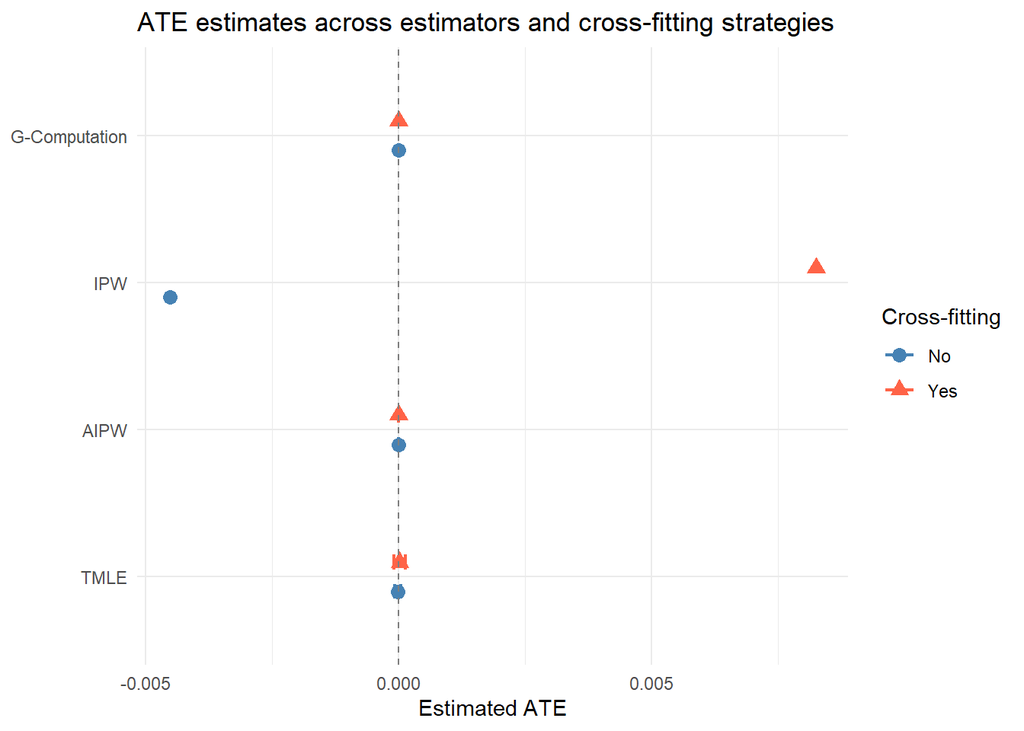

```r
# ── Forest-style plot ─────────────────────────────────────────────────────────
results %>%
  mutate(Estimator = factor(Estimator, levels = rev(c("G-Computation", "IPW", "AIPW", "TMLE")))) %>%
  ggplot(aes(x = ATE, y = Estimator, color = Cross_fitting, shape = Cross_fitting)) +
  geom_point(size = 3, position = position_dodge(width = 0.4)) +
  geom_errorbarh(aes(xmin = CI_lower, xmax = CI_upper),
                 height = 0.2, linewidth = 0.8,
                 position = position_dodge(width = 0.4),
                 na.rm = TRUE) +
  geom_vline(xintercept = 0, linetype = "dashed", color = "grey50") +
  scale_color_manual(values = c("steelblue", "tomato")) +
  theme_minimal() +
  labs(x = "Estimated ATE", y = NULL, color = "Cross-fitting", shape = "Cross-fitting",
       title = "ATE estimates across estimators and cross-fitting strategies")
```